# Find CNV losses that overlap with TP53 domains

K S Gaonkar (D3B)

In this script we will find CNV losses that overlap with TP53 domains:

- TAD = trans-activating domain (essential for function)
- DBD = DNA-binding domain (residues 102–292)
- TD = tetramerization domain (residues 326–356)

We want to subset CNV calls where the domain are lost which will possibly lead to loss of function to use for evaluation of TP53 inactivation score at a later step.

### Setup

```r
library("ggpubr")
library("ggthemes")
library("tidyverse")
# rootdir
root_dir <- rprojroot::find_root(rprojroot::has_dir(".git"))
data_dir <- file.path(root_dir, "data")
results_dir <- file.path(root_dir,
                         "analyses",
                         "tp53_nf1_score",
                         "results")

if (!dir.exists(results_dir)) {
  dir.create(results_dir)
}
```

### Input files

Read in CNV files with status and location-domain overlap file

```r
# consensus seg for file for the location of CNVs (WGS samples)
t_only <- read_rds(file.path(root_dir,
                                    "data",
                                    "Hope-cnv-controlfreec-tumor-only.rds"))

consensus_seg <- read_rds(file.path(root_dir,
                                    "data",
                                    "Hope-cnv-controlfreec.rds")) %>%
  bind_rows(t_only)


# Gene location and domain overlap file
bioMartDataPfamTp53 <-
  readRDS(system.file("extdata", "pfamDataBioMart.RDS", package = "annoFuseData")) %>%
  dplyr::filter(hgnc_symbol=="TP53")
```

Read in histology file. Subset based on experimental strategy so that all samples have the correct CNV status file to use.

```r
# histology file

clinical<-read_tsv(file.path(data_dir,"Hope-GBM-histologies-base.tsv"))
histologies_df <- clinical %>%
  dplyr::select(Kids_First_Participant_ID, Kids_First_Biospecimen_ID, sample_id, composition, tumor_descriptor)

# find the WGS samples + WXS samples and subset "_with_status.tsv" file with that
DNA_samples <- clinical %>% dplyr::filter(sample_type == "Tumor") %>%
  dplyr::filter(experimental_strategy %in% c("WGS", "WXS")) %>%
  dplyr::pull("Kids_First_Biospecimen_ID")

# Filter the consensus and the cnvkit seg files to contain only either WGS or WXS samples
DNA_seg <- consensus_seg %>%
  dplyr::filter(Kids_First_Biospecimen_ID %in% DNA_samples)


# Read in scores from tp53-nf1-classifier
score_df <- read_tsv(file.path(results_dir, "combined_scores.tsv")) %>%
  select(!sample_id) %>%
  left_join(histologies_df,by=c("Kids_First_Biospecimen_ID")) %>%
  as.data.frame()
```

Generating genomics ranges for cnv and domain dataframes

```r
# Genomic range for cnv seg file
cnv_gr <- DNA_seg %>%
  dplyr::rename(copy_number = `copy number`) %>%
  GenomicRanges::makeGRangesFromDataFrame(keep.extra.columns = TRUE,
                                          starts.in.df.are.0based = FALSE)

# Genomic range for gene location and domain overlap file
domain_gr <- bioMartDataPfamTp53 %>%
  dplyr::filter(!is.na(domain_start),!is.na(domain_end)) %>%
  # formatting strand information
  dplyr::mutate(strand = if_else(strand=="-1","-","+")) %>%
  dplyr::rename(chr = chromosome_name, start = domain_start, end = domain_end) %>%
  GenomicRanges::makeGRangesFromDataFrame(keep.extra.columns = TRUE,
                                          starts.in.df.are.0based = FALSE)
```

### Overlap CNV and TP53 Domain ranges

```r
# overlap cnv and domain
overlaps <- IRanges::mergeByOverlaps(cnv_gr, domain_gr)

# get CNV and domain overlap per BS id
annotated_cn <- data.frame(
  biospecimen_id = overlaps$Kids_First_Biospecimen_ID,
  status = overlaps$status,
  copy_number = overlaps$copy_number,
  #ploidy = overlaps$tumor_ploidy,
  hgnc_symbol = overlaps$hgnc_symbol,
  pfam_id = overlaps$pfam_id,
  NAME = overlaps$NAME,
  stringsAsFactors = FALSE
) %>%
  dplyr::distinct() %>%
  # select loss that overlaps the TP53 core domains
  dplyr::filter(status=="loss") %>%
  dplyr::group_by(biospecimen_id,copy_number) %>%
  # summarise domain NAME per biospecimen_id TP53 loss
  dplyr::summarise(
    domain=toString(NAME)) %>%
  left_join(histologies_df,by=c("biospecimen_id"="Kids_First_Biospecimen_ID")) %>%
  left_join(score_df,by=c("Kids_First_Participant_ID", "sample_id", "composition", "tumor_descriptor")) %>%
  unique()
```

[output not shown]

### Copy number overlapping TP53 domain

We want to check if classifier scores support CNV calls and if support from classifier (higher inactivation score) can be used to filter TP53 loss calls

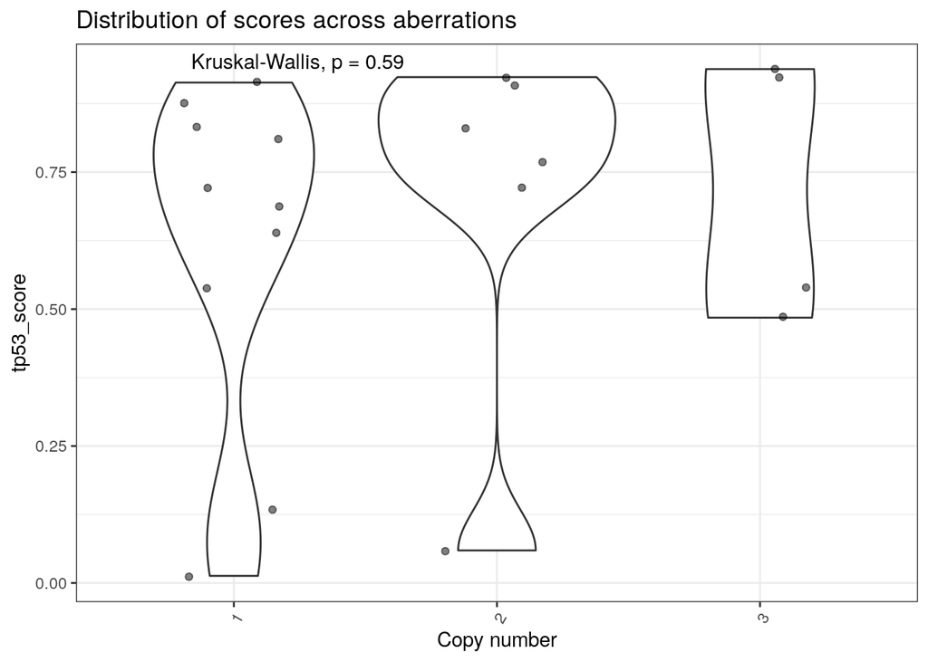

```r
ggplot(annotated_cn, aes(x = factor(copy_number), y = tp53_score)) +
  geom_violin()+
  geom_jitter(alpha = 0.5, width = 0.2) +
  stat_compare_means() +
  theme_bw() +
  ggtitle("Distribution of scores across aberrations") +
  theme(axis.text.x = element_text(angle = 60, hjust = 1))+
  xlab("Copy number")
```

### Save high confidence TP53 loss in file

```r
annotated_cn %>%
  # high confidence CNV losses
  # with high TP53 inactivation score
  dplyr::filter(copy_number<=1) %>%
  # remove columns
  dplyr::select(-tp53_score,-Kids_First_Biospecimen_ID) %>%
  unique() %>%
  write_tsv(file.path(results_dir,"loss_overlap_domains_tp53.tsv"))
```